# A Model to Predict the Next Word: Milestone Report

Nam Nguyen

August 5, 2017

## Overview

The project is to build a model to predict the next word of a word sequence. The model was based on the English versions of blogs, news, and twitters in the Coursera-Swiftkey dataset. Sampling the dataset resulted in a reduced dataset so that the computing time and resoures were manageable. After some exploring of the raw data, preprocessing the texts included converting to plain text and lowercase, expanding contraction, and removing profanities, numbers, and punctuation. From the clean data, three sets of unigrams, bigrams, and trigrams were generated and explored. The distribution of these ngrams indicated the prevalence of English stopwords. The next step will be building a predicting model based on these ngrams.

## Exploring CourseraSwitkey Dataset

The Coursera-Swiftkey dataset consists of three text files of blogs, news, and twitters in English. Each line in these files is a blog, a news item, or a tweet.

```
##         Number_of_Lines Number_of_Words Words_per_Line
## Blogs            899288        38154238       42.42716
## News              77259         2693898       34.86840
## Twitter         2360148        30218166       12.80350
## Total           3336695        71066302       21.29841
```

As the numbers of words per line in the above table indicate, blogs tend to be long while tweets are short. News items are likely short pieces instead of full articles because these items have fewer words than blogs on the average.

## Sampling and Splitting Data Set

The whole data set has about 3.3 million lines and 71 million words. Sampling the data set for modeling was necessary to allow manageable computing resources and time. The sample size was 10 percent of the whole set. The blogs, news, and twitters were sampled separately, and the raw data for modeling was the three samples combined.

```
##            Number_of_Lines Number_of_Words Words_per_Line
## Training            200199         4268172       21.31965
## Validation           66732         1405436       21.06090
## Testing              66736         1433202       21.47570
## Total               333667         7106810       21.29911
```

The raw data was permutated and split 60:20:20 for training, validation, and testing. The numbers of words per line in the training, valiation, and testing datasets are similar to the number of words per line of the unsampled dataset.

## Cleaning Data

Cleaning data was necessary to convert the data into plain text and lowercase. Word contractions were replaced by their full forms according to the [qdap](https://trinkerrstuff.wordpress.com/my-r-packages/qdap/) library. Profanities, numbers, and punctuations were removed. As Claudia Feigenbaum suggested in the Coursera Discussion Forum, the Google’s banned word list was downloaded [here](https://gist.github.com/ryanlewis/a37739d710ccdb4b406d).

Before cleaning, three lines of the training data are as follows:

```
## <<SimpleCorpus>>
## Metadata:  corpus specific: 1, document level (indexed): 0
## Content:  documents: 3
##
## [1] Dueling 50 Shades interviews...oddly, I don't care about either of them!
## [2] Mario Kart DSMario Kart
## [3] why haven't the NIck Parents' Pick winners been announced? i'm dying here...
```

After cleaning, the same three lines of the training data are as follows:

```
## <<SimpleCorpus>>
## Metadata:  corpus specific: 1, document level (indexed): 0
## Content:  documents: 3
##
## [1] dueling shades interviews oddly i do not care about either of them
## [2] mario kart dsmario kart
## [3] why haven t the nick parents pick winners been announced i am dying here
```

Inspecting three lines in the training data before and after cleaning shows instances of lowercase conversion, contraction replacement, and number and punctuation removal. The qdap library may miss some contractions not defined in the library.

The validation and testing data will be processed with the same cleaning procedure.

## Tokenizing the training data

Unigrams, bigrams, and trigrams were generated from the training data with the help of the [ngram](https://cran.r-project.org/web/packages/ngram/ngram.pdf) library.

### Exploring unigrams

A summary of the unigrams and the word cloud of twenty most frequent unigrams are below.

```
##              Number_of_Words Fraction_of_Total Probability
## All                   112773            1.0000      1.0000
## Freq >=  10            17604            0.1561      0.9554
## Freq >=  25             9738            0.0864      0.9272
## Freq >=  50             6004            0.0532      0.8967
## Freq >=  100            3542            0.0314      0.8564
```

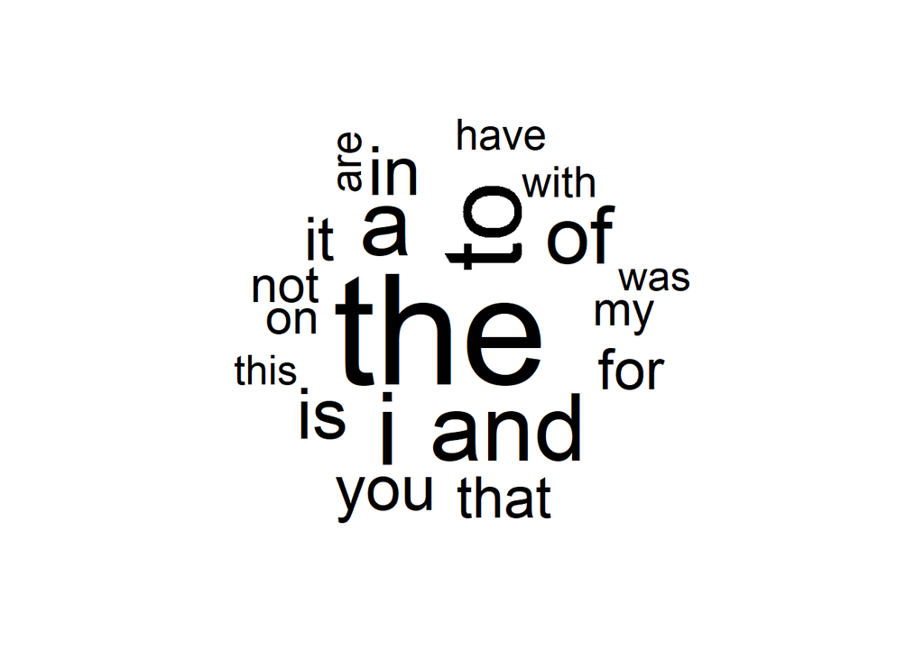

About 10000 unigrams with frequencies greater than 25 or about 9 percent of unigrams account for about 93 percent of all occurrences. The word cloud shows that most frequent unigrams are English stopwords.

### Exploring Bigrams

A summary of the bigrams and the word cloud of twenty most frequent bigrams are below.

```
##              Number_of_Words Fraction_of_Total Probability
## All                  1387711            1.0000      1.0000
## Freq >=  10            45501            0.0328      0.5381
## Freq >=  25            16888            0.0122      0.4394
## Freq >=  50             7857            0.0057      0.3672
## Freq >=  100            3559            0.0026      0.2978
```

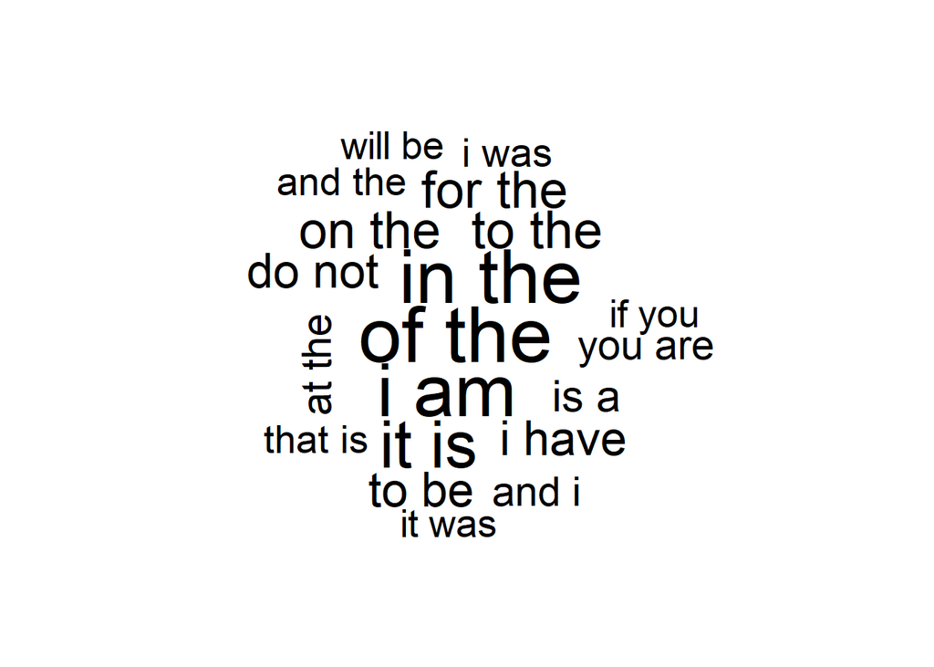

About 17000 bigrams with frequencies greater than 25 or about 1 percent of bigrams account for about 44 percent of all occurrences. Again, bigrams of English stopwords are the most frequent terms.

### Exploring Trigrams

A summary of the trigrams and the word cloud of twenty most frequent trigrams are below.

```
##              Number_of_Words Fraction_of_Total Probability
## All                  3080780            1.0000      1.0000
## Freq >=  10            22728            0.0074      0.1477
## Freq >=  25             6221            0.0020      0.0920
## Freq >=  50             2261            0.0007      0.0606
## Freq >=  100             754            0.0002      0.0365
```

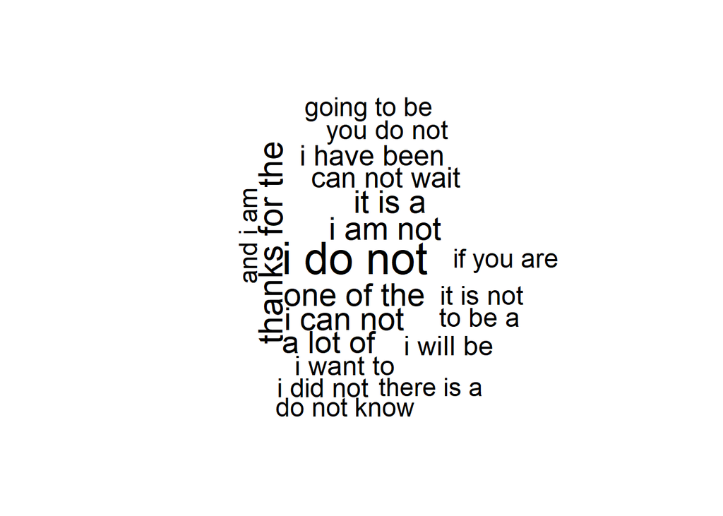

About 6000 trigrams with frequencies greater than 25 or about 0.2 percent of trigrams account for about 9 percent of all occurrences. Trigrams of English stopwords are also among the most frequent terms.

A summary of fractions of frequent ngrams in the three sets of unigrams, bigrams, and trigrams is as follows.

```
##                      top20 top100 top10000 top50000 top100000
## Fraction of 1-grams 0.2900 0.4891   0.9287   0.9846    0.9970
## Fraction of 2-grams 0.0356 0.0828   0.3895   0.5476    0.6192
## Fraction of 3-grams 0.0048 0.0130   0.1101   0.1921    0.2392
```

For the unigrams, the top 100 words account for 49 percent while the top 10,000 words account for 93 percent of all occurences. For the bigrams and trigrams, the top 100,000 fractions are 62 and 24 percent, respectively. Results from exploring the unigrams indicate that a set of top 10,000 unigrams is appropriate as the basis for the prediction model.

## Modeling the N-gram Predictors

The next step will be setting up the n-gram predictors. I am reviewing the [Cornell lecture on n-gram models](http://www.cs.cornell.edu/courses/cs4740/2014sp/lectures.htm) to learn more about probability of a word sequence, smoothing techniques, and backoff method.